# Statistical Learning for Data Science Exam

26 June, 2025

The duration of the exam is 120 minutes. For most exercises you are required to provide R code: write your code in the assigned R code chunk. For some exercises you are required to provide a textual answer: type your answer in the space that follows

**Your answer**.

In the following R chunk please fill in the required information otherwise the file will not be knitted

```r
matricola <- 123456
name <- 'Nicola'
surname <- 'Lunardon'
if (!exists("matricola") | !exists("name") | !exists("surname"))
  stop("Please, insert your information in the first chunk.")
```

```r
library(SLDS2425)
library(tidyverse)
```

# Exercise 1

Autism, also known as autism spectrum disorder, is a neurodevelopmental disorder characterized by differences or difficulties in social communication and interaction, a preference for predictability and routine, sensory processing differences, focused interests, and repetitive behaviors. We have at our disposal a dataset `autism_screening` from a large screening study of autism. The dataset includes the questionnaire results as well as relevant demographical information. Load the dataset by typing `data(autism_screening)` and answer the following questions.

## a)

How many cases of autism are present in the dataset?

**Your answer:**

```r
data(autism_screening)
autism_screening%>% group_by(autism) %>% summarise(c = n())
```

```
## # A tibble: 2 × 2
##   autism     c
##   <fct>  <int>
## 1 no       613
## 2 yes       91
```

## b)

Does there seem to a relation between gender and the prevalence of autism? Investigate this hypothesis with a suitable graphical display of data and a numerical summary.

**Your answer:**

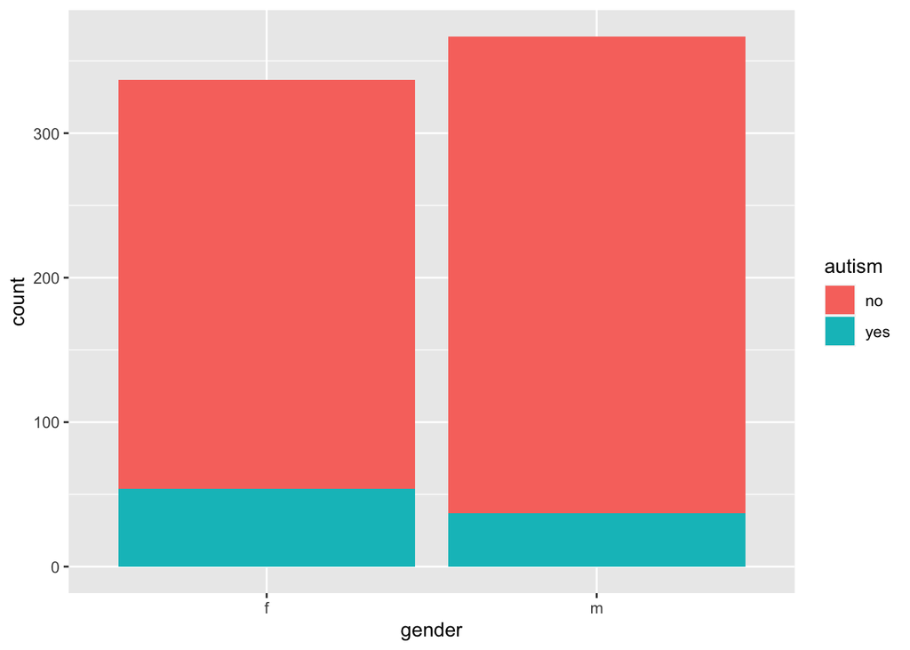

```r
ggplot(autism_screening) +
  geom_bar(aes(x= gender, fill = autism))
```

```r
autism_screening %>% group_by(gender,autism)  %>% summarise(c = n())
```

```
## # A tibble: 4 × 3
## # Groups:   gender [2]
##   gender autism     c
##   <fct>  <fct>  <int>
## 1 f      no       283
## 2 f      yes       54
## 3 m      no       330
## 4 m      yes       37
```

## c)

Is there a relation between age and autism? Again, investigate this hypothesis with both numerical and graphical data summaries.

**Your answer:**

```r
fit1 <- lm(age ~ autism, data = autism_screening)
summary(fit1)
```

```
##
## Call:
## lm(formula = age ~ autism, data = autism_screening)
##
## Residuals:
##    Min     1Q Median     3Q    Max
## -16.76  -8.09  -3.09   4.24 353.91
##
## Coefficients:
##             Estimate Std. Error t value Pr(>|t|)
## (Intercept)  29.0933     0.6653  43.731   <2e-16 ***
## autismyes     4.6650     1.8478   2.525   0.0118 *
## ---
## Signif. codes:  0 '***' 0.001 '**' 0.01 '*' 0.05 '.' 0.1 ' ' 1
##
## Residual standard error: 16.44 on 700 degrees of freedom
##   (2 observations deleted due to missingness)
## Multiple R-squared:  0.009023,   Adjusted R-squared:  0.007608
## F-statistic: 6.374 on 1 and 700 DF,  p-value: 0.0118
```

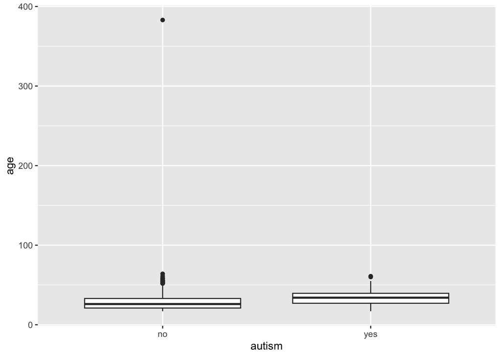

```r
ggplot(data = autism_screening) +
  geom_boxplot(mapping = aes(x = autism, y = age))
```

## d)

Do you notice something unusual about the variable `age`? What is a plausible explanation?

**Your answer:**

## e)

How many different countries of residence are present in the dataset?

**Your answer:**

```r
autism_screening %>% group_by(contry_of_res) %>% summarise(n())
```

```
## # A tibble: 67 × 2
##    contry_of_res `n()`
##    <fct>         <int>
##  1 Afghanistan      13
##  2 AmericanSamoa     2
##  3 Angola            1
##  4 Argentina         2
##  5 Armenia           2
##  6 Aruba             1
##  7 Australia        27
##  8 Austria           4
##  9 Azerbaijan        1
## 10 Bahamas           2
## # ℹ 57 more rows
```

## f)

What ethnicity shows the highest prevalence of autism?

**Your answer:**

```r
autism_screening  %>% mutate(aut1 =  ifelse(autism == "yes", 1, 0)) %>% group_by(ethnicity) %>%
   summarise(mean(aut1))
```

```
## # A tibble: 12 × 2
##    ethnicity         `mean(aut1)`
##    <fct>                    <dbl>
##  1 "?"                     0.0632
##  2 "Asian"                 0.0407
##  3 "Black"                 0.116
##  4 "Hispanic"              0.0769
##  5 "Latino"                0.4
##  6 "Middle Eastern "       0.0978
##  7 "others"                0
##  8 "Others"                0.0667
##  9 "Pasifika"              0.167
## 10 "South Asian"           0.0556
## 11 "Turkish"               0.167
## 12 "White-European"        0.215
```

## g)

Columns 1-10 represent scores on a questionnaire used by health professionals to screen for autism. Does the total score `total` represent a useful information for predicting the presence of autism? What plots are useful to get a tentative answer? What formal statistical tools can you use to answer this question?  
How do you asses the significance of your findings?

**Your answer:**

```r
fit2 <- lm(result ~ autism, data = autism_screening)
summary(fit2)
```

```
##
## Call:
## lm(formula = result ~ autism, data = autism_screening)
##
## Residuals:
##    Min     1Q Median     3Q    Max
## -5.121 -1.690 -0.690  1.879  5.310
##
## Coefficients:
##             Estimate Std. Error t value Pr(>|t|)
## (Intercept)  4.69005    0.09922  47.267  < 2e-16 ***
## autismyes    1.43083    0.27598   5.184 2.84e-07 ***
## ---
## Signif. codes:  0 '***' 0.001 '**' 0.01 '*' 0.05 '.' 0.1 ' ' 1
##
## Residual standard error: 2.457 on 702 degrees of freedom
## Multiple R-squared:  0.03688,    Adjusted R-squared:  0.0355
## F-statistic: 26.88 on 1 and 702 DF,  p-value: 2.836e-07
```

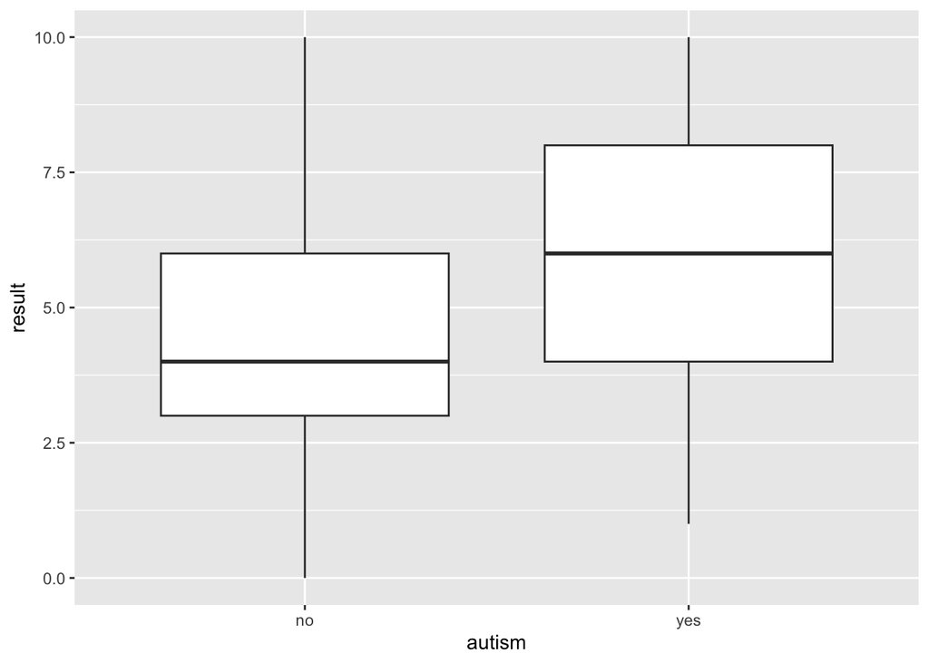

```r
ggplot(autism_screening)+
  geom_boxplot(mapping = aes(x = autism, y = result))
```

# Exercise 2

A data analyst has processed some data regarding supermarket sales (in dollars) of two categories of pasta, “FreshCutPasta” and “FreshNoodles”. The response variable is a dummy variable that takes the value ‘0’ if the sales of “FreshCutPasta” are greater than those of “FreshNoodles” and ‘1’ otherwise. The covariate is categorical and refers to the different ingredients used to make the pasta: ‘plain’ (wheat) and “whole” (whole wheat). In the chunk below you are given some information regarding the output of the analysis, in particular

- the summary of a logistic regression model estimated by the analyst. Some entries are purposedly shown as ‘NA’
- the vector with the values of the response variable (the variable containing the values is called `pasta`)
- the vector with the values of the explanatory variable (the variable containing the values is called `flavour`)

To visualize the summary and get access to the variables containing the values of the response variable and of the explanatory variable *you have to compile the code*.

```r
library(SLDS2425)
set.seed(matricola)
obj <- slds.fun(matricola, 1)
```

```
##
## Call:
## glm(formula = pasta ~ flavour, family = binomial)
##
## Coefficients:
##                     Estimate Std. Error z value Pr(>|z|)
## (Intercept)           1.3863     0.7906   1.754       NA
## flavour whole wheat  -2.2336     1.0494  -2.128       NA
##
## (Dispersion parameter for binomial family taken to be 1)
##
##     Null deviance: 27.526  on 19  degrees of freedom
## Residual deviance: 22.225  on 18  degrees of freedom
## AIC: 26.225
##
## Number of Fisher Scoring iterations: 4
```

```r
pasta <- obj$pasta
flavour <- obj$flavour
```

## (a)

By using the information included in the summary above, provide the interpretation of the coefficients in the model in terms of the odds ratio (no coding needed, just plain text)

**Your answer**: The odds ratio is defined as
$$\frac{P(Y=1|\text{flavour=z})}{P(Y=0|\text{flavour=z})}=\exp({\beta_0+\beta_1
z})$$
where $\beta_0$ and $\beta_1$ are the parameters of the model and $z$ is the specific values assumed with the covariate `flavour`. Since the covariate is categorical with two categories, it can be viewed as a dummy variable with two levels. By looking at the summary, we have that the reference category is `wheat`, meaning that when `flavour=wheat` then z=0, whereas when `flavour=wheat` then z=1. This entails that the intercept is gauging what is the change in the odds ratio when the ingredient is just `wheat`. The coefficient associated to the category `whole wheat` gauges how the odds ratio is changing with respect to the reference category. If the coefficient for category `whole wheat` is greater than zero then the odds for that category are higher than for the reference category, lower otherwise. In the given example, when the ingredient is `whole wheat`, the chances to sell more “FreshNoodles” than “FreshCutPasta” (Y=1) are lower compared to the case where thge ingredient is `wheat`.

## (b)

By using the information included in the summary of the estimated logistic regression model, state whether it is more likely to sell more `FreshNoodles` than `FreshCutPasta` when the ingredient is `wheat` or `whole wheat`

**Your answer**: If we sell more `FreshNoodles` than `FreshCutPasta` then the response variable is equal to 1 by its definition. We are asked to compute the probability, according to the model, of the response being equal to 1 when `flavour` is equal to either `wheat` or `whole wheat`. Those probabilities are equal to the logistic function for each category of `flavour`

- $P(Y=1|\text{flavour=wheat})$= exp(1.3863)/(1+exp(1.3863))=0.8
- $P(Y=1|\text{flavour=whole wheat})$= exp(1.3863-2.2336)/(1+exp(1.3863-2.2336))=0.3

It is more likely to sell more `FreshNoodles` than `FreshCutPasta`, i.e. $Y=1$, when the ingredient is just wheat.

## (c)

Given that the significance of the coefficients is not given in the summary, run a suitable exploratory analysis in order to gain some insights regarding the usefulness of the explanatory variable. Motivate your answer.

**Your answer**:

```r
prop.table(table(flavour, pasta), margin=2)
```

```
##               pasta
## flavour                0         1
##    wheat       0.7272727 0.2222222
##    whole wheat 0.2727273 0.7777778
```

## (d)

Establish whether a logistic regression model with the intercept only is to be preferred to the model that includes the explanatory variable `flavour`. Estimate the models, compare them by using a suitable metric and motivate your answer.

**Your answer**:

```r
fit.null <- glm(pasta~1, family = binomial)
fit <- glm(pasta~flavour, family = binomial)
AIC(fit.null)
```

```
## [1] 29.52555
```

```r
AIC(fit)
```

```
## [1] 26.22533
```

We estimate the models to be compared by using the data provided in the first chunk of exercise 2. The model with the intercept only is the model that does not include the explanatory variable. We perform the comparison between the two models by using the Akaike information criterion and choose the model with smalles AIC. So the model with the intercept only has not to be preferred to the one including the explanatory variable `flavour`.

# Exercise 3

The `leukemia` dataset contains gene expression data to be used to classify cancer types. The available data consists of 72 tissue samples biopsy (the statistical units) and of 3572 covariates, corresponding to the expression of 3572 genes. The dataset contains

- The response variable `Y`: it takes on the values 0 (no cancer) and 1 (cancer)
- The predictors `x.1` to `x.3572`: each predictor take values on the real line. The values indicates the level of expression of the corresponding gene.

The aim of the analysis consists in building a classifier to predict the whether a patient has a tumor based on a tissue sample biopsy and the gene expression data that can be obtained from it.

## (a)

Do not modify this chunk.

```r
library(SLDS2425)
data(leukemia)
out <- slds.fun(matricola, 2, leukemia)
```

A Lasso regression model has been fit to the data. The best fit includes just two covariates, not including the intercept, and the estimated coefficients are

- 1.361 for variable x.60
- -1.802 for variable x.42

Argue whether the value of the penalty parameter equal to 1 allows to get the given estimates (just text, no code needed)

**Your answer**: In a Lasso regression the constraint the parameters, excluding the intercept, must satisfy is
$$\sum_{j=1}^p |\beta_j|\leq\lambda$$
where $\beta_j$ is the parameter associated to covariate $X_j$ and $\lambda$ is the penalty tuning parameter in the Lasso regression. Since 3.163 is greater than 1 we have that the provided value of the penalty parameter does not allow to get those estimates.

## (b)

Consider the variables x.60 and x.42. Discuss whether or not the variables should be standardized prior to fit a Lasso regression model. You can use both code and text. Motivate your answer

```r
var(leukemia$x.60)
```

```
## [1] 0.1236837
```

```r
var(leukemia$x.42)
```

```
## [1] 0.2240698
```

It is a good pratice to standardize the explanatory variables prior to estimate the models as to ensure that the penalty is sensible (the actual value of coefficient estimates depend on the predictor’s scale). In this case the variability of the two predictors do not differ too much, so the variables could be used as they are. That being said, it is always good pratice to standardize the predictors (as it can be time consuming to assess whether or not predictors have to be standardized when the number of predictors is large).

## (c)

Estimate a statistical model by using shrinkage methods. Select the best model according to a suitable criteria.

**Your answer**:

```r
library(glmnet)
#just to check the distribution of the response
table(leukemia$Y)
```

```
##
##  0  1
## 47 25
```

```r
#roughly 1/3 of the tissue sample contain cancer cells


leukemia$Y <- as.factor(leukemia$Y)
#create model matrix (covariates) and the response
which(names(leukemia)=="Y")
```

```
## [1] 1
```

```r
#the response is in the first column
##we scale the predictors
X <- scale(as.matrix(leukemia[,-1]))
y <- leukemia$Y

#create a test set to evaluate the performance of the classifier later on
ids <- sample(1:nrow(leukemia), round(nrow(leukemia)*0.8), replace=FALSE)


X.train <- X[ids,]
X.test <- X[-ids,]

y.train <- y[ids]
y.test <- y[-ids]

#check the distribution of the response in the training set and test set
table(y.train)
```

```
## y.train
##  0  1
## 38 20
```

```r
table(y.test)
```

```
## y.test
## 0 1
## 9 5
```

```r
#go with the Lasso as to perform variable selection as we have a large number of variables
#run cross validation to select the best model
fitlassocv <- cv.glmnet(X.train, y.train, alpha = 1, family="binomial")
#choose the best model according to the one standard deviation rule. Do not display the coefficients: too large output
my.coefs <- coef(fitlassocv, s = "lambda.1se")
```

## (d)

Build a classifier to predict whether a sample of tissue contains cancer cells. Evaluate the overall prediction accuracy of the proposed classifier. Comment on the results.

**Your answer**:

```r
preds <- predict(fitlassocv, X.test, s = "lambda.1se", type="class")
#create the confusion matrix
(tab <- table(preds, y.test))
```

```
##      y.test
## preds 0 1
##     0 9 0
##     1 0 5
```

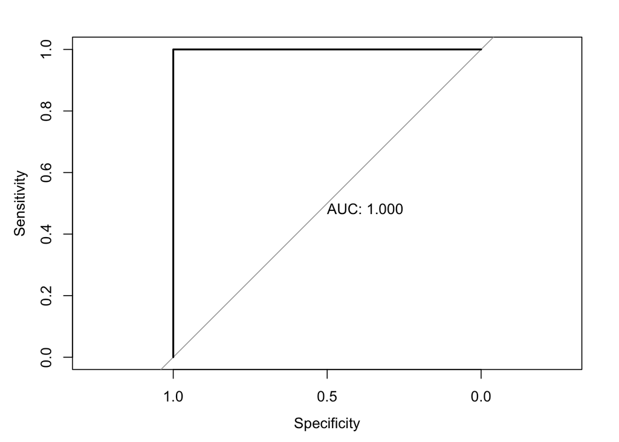

```r
library(pROC)
preds.resp <- predict(fitlassocv, X.test, s = "lambda.1se", type="response")
mul_roc <- roc(y.test ~ preds.resp,plot=TRUE,print.auc=TRUE)
```

By looking at the confusion matrix the predictions are in fact oracle predictions. The overall performance of the classifier is excellent as the ROC curve shows that for any given threshold set to classify the observations (AUC=1).

# Session Info

Do not modify the chunk below

```r
Sys.info()
```

```
##                                                                                                  sysname
##                                                                                                 "Darwin"
##                                                                                                  release
##                                                                                                 "24.5.0"
##                                                                                                  version
## "Darwin Kernel Version 24.5.0: Tue Apr 22 19:48:46 PDT 2025; root:xnu-11417.121.6~2/RELEASE_ARM64_T8103"
##                                                                                                 nodename
##                                                                                         "enigma-2.local"
##                                                                                                  machine
##                                                                                                  "arm64"
##                                                                                                    login
##                                                                                                   "root"
##                                                                                                     user
##                                                                                         "nicolalunardon"
##                                                                                           effective_user
##                                                                                         "nicolalunardon"
```

```r
#last compiled
date()
```

```
## [1] "Thu Jun 26 06:52:50 2025"
```

```r
#student info
paste(name, surname, "-", matricola, sep=" ")
```

```
## [1] "Nicola Lunardon - 123456"
```